# Multi-Class Image Classification Model for Vegetable Image Dataset Using TensorFlow Take 3

### January 27, 2022

Template Credit: Adapted from a template made available by Dr. Jason Brownlee of Machine Learning Mastery. [https://machinelearningmastery.com/]

SUMMARY: This project aims to construct a predictive model using a TensorFlow convolutional neural network (CNN) and document the end-to-end steps using a template. The Vegetable Image Dataset is a multi-class classification situation where we attempt to predict one of several (more than two) possible outcomes.

INTRODUCTION: From vegetable production to delivery, common steps such as picking and sorting vegetables often occur manually. The research team wanted to improve the operation by developing a deep neural network model to detect and classify vegetables. That model can be implemented within different types of devices and can also solve other problems related to identifying vegetables, like labeling the vegetables automatically without any need for human work.

The initial experiment looked at 15 types of common vegetables found throughout the world. The vegetables chosen for the experimentation include bean, bitter gourd, bottle gourd, brinjal, broccoli, cabbage, capsicum, carrot, cauliflower, cucumber, papaya, potato, pumpkin, radish, and tomato. A total of 21000 images from 15 classes are used, where each class contains 1400 images of size 224×224 and in JPG format. The dataset split 70% for training, 15% for validation, and 15% for testing purposes.

ANALYSIS: The performance of the baseline model achieved an accuracy score of 95.53% after ten epochs using the validation datasets. After tuning the hyperparameters, the best model processed the validation dataset with an accuracy score of 99.70%. Furthermore, the final model processed the test dataset with an accuracy measurement of 98.67%.

CONCLUSION: In this iteration, the TensorFlow VGG19 CNN model appeared to be suitable for modeling this dataset. We should consider experimenting with TensorFlow for further modeling.

Dataset Used: Vegetable Image Dataset

Dataset ML Model: Multi-class image classification with numerical attributes

Dataset Reference: https://www.kaggle.com/misrakahmed/vegetable-image-dataset

One potential source of performance benchmarks: https://www.kaggle.com/misrakahmed/vegetable-image-dataset/code

# Task 1 - Prepare Environment

```python
# # Install the packages to support accessing environment variable and SQL databases
# !pip install python-dotenv PyMySQL boto3
```

```python
# Retrieve GPU configuration information
gpu_info = !nvidia-smi
gpu_info = '\n'.join(gpu_info)
if gpu_info.find('failed') >= 0:
    print('Select the Runtime → "Change runtime type" menu to enable a GPU accelerator, ')
    print('and then re-execute this cell.')
else:
    print(gpu_info)
```

```
Sun Jan 23 20:57:55 2022
+-----------------------------------------------------------------------------+
| NVIDIA-SMI 460.91.03    Driver Version: 460.91.03    CUDA Version: 11.4     |
|-------------------------------+----------------------+----------------------+
| GPU  Name        Persistence-M| Bus-Id        Disp.A | Volatile Uncorr. ECC |
| Fan  Temp  Perf  Pwr:Usage/Cap|         Memory-Usage | GPU-Util  Compute M. |
|                               |                      |               MIG M. |
|===============================+======================+======================|
|   0  Quadro RTX 5000     Off  | 00000000:00:05.0 Off |                  Off |
| 33%   32C    P8    10W / 230W |      0MiB / 16125MiB |      0%      Default |
|                               |                      |                  N/A |
+-------------------------------+----------------------+----------------------+

+-----------------------------------------------------------------------------+
| Processes:                                                                  |
|  GPU   GI   CI        PID   Type   Process name                  GPU Memory |
|        ID   ID                                                   Usage      |
|=============================================================================|
|  No running processes found                                                 |
+-----------------------------------------------------------------------------+
```

```python
# Retrieve memory configuration information
from psutil import virtual_memory
ram_gb = virtual_memory().total / 1e9
print('Your runtime has {:.1f} gigabytes of available RAM\n'.format(ram_gb))

if ram_gb < 20:
    print('To enable a high-RAM runtime, select the Runtime → "Change runtime type"')
    print('menu, and then select High-RAM in the Runtime shape dropdown. Then, ')
    print('re-execute this cell.')
else:
    print('You are using a high-RAM runtime!')
```

```
Your runtime has 31.6 gigabytes of available RAM

You are using a high-RAM runtime!
```

```python
# Retrieve CPU information from the system
ncpu = !nproc
print("The number of available CPUs is:", ncpu[0])
```

```
The number of available CPUs is: 8
```

```python
# # Mount Google Drive locally for loading the dotenv files
# from dotenv import load_dotenv
# from google.colab import drive
# drive.mount('/content/gdrive')
# gdrivePrefix = '/content/gdrive/My Drive/Colab_Downloads/'
# env_path = '/content/gdrive/My Drive/Colab Notebooks/'
# dotenv_path = env_path + "python_script.env"
# load_dotenv(dotenv_path=dotenv_path)
```

## 1.a) Load libraries and modules

```python
# Set the random seed number for reproducible results
RNG_SEED = 88
```

```python
import random
random.seed(RNG_SEED)
import numpy as np
np.random.seed(RNG_SEED)
import pandas as pd
import matplotlib.pyplot as plt
import matplotlib.image as mpimg
import os
import sys
import math
# import boto3
import zipfile
from datetime import datetime
from sklearn.metrics import classification_report
from sklearn.metrics import confusion_matrix
from sklearn.metrics import accuracy_score

import tensorflow as tf
tf.random.set_seed(RNG_SEED)
from tensorflow import keras
from tensorflow.keras.callbacks import ReduceLROnPlateau
from tensorflow.keras.preprocessing.image import ImageDataGenerator
```

## 1.b) Set up the controlling parameters and functions

```python
# Begin the timer for the script processing
START_TIME_SCRIPT = datetime.now()
```

```python
# Set up the number of CPU cores available for multi-thread processing
N_JOBS = 1

# Set up the flag to stop sending progress emails (setting to True will send status emails!)
NOTIFY_STATUS = False

# Set the percentage sizes for splitting the dataset
TEST_SET_RATIO = 0.2
VAL_SET_RATIO = 0.2

# Set the number of folds for cross validation
N_FOLDS = 5
N_ITERATIONS = 1

# Set various default modeling parameters
DEFAULT_LOSS = 'categorical_crossentropy'
DEFAULT_METRICS = ['accuracy']
DEFAULT_OPTIMIZER = tf.keras.optimizers.Adam(learning_rate=0.0001)
CLASSIFIER_ACTIVATION = 'softmax'
MAX_EPOCHS = 10
BATCH_SIZE = 32
NUM_CLASSES = 15
CLASS_LABELS = ['Bean','Bitter_Gourd','Bottle_Gourd','Brinjal','Broccoli',
                'Cabbage','Capsicum','Carrot','Cauliflower','Cucumber',
                'Papaya','Potato','Pumpkin','Radish','Tomato']
# CLASS_NAMES = []
# RAW_IMAGE_SIZE = (1280, 720)
TARGET_IMAGE_SIZE = (224, 224)
INPUT_IMAGE_SHAPE = (TARGET_IMAGE_SIZE[0], TARGET_IMAGE_SIZE[1], 3)

# Define the labels to use for graphing the data
TRAIN_METRIC = "accuracy"
VALIDATION_METRIC = "val_accuracy"
TRAIN_LOSS = "loss"
VALIDATION_LOSS = "val_loss"

# Define the directory locations and file names
STAGING_DIR = 'staging/'
TRAIN_DIR = 'staging/Vegetable_Images/train/'
VALID_DIR = 'staging/Vegetable_Images/validation/'
TEST_DIR = 'staging/Vegetable_Images/test/'
TRAIN_DATASET = 'Vegetable_Images.zip'
# VALID_DATASET = ''
# TEST_DATASET = ''
# TRAIN_LABELS = ''
# VALID_LABELS = ''
# TEST_LABELS = ''
# OUTPUT_DIR = 'staging/'
# SAMPLE_SUBMISSION_CSV = 'sample_submission.csv'
# FINAL_SUBMISSION_CSV = 'submission.csv'

# Check the number of GPUs accessible through TensorFlow
print('Num GPUs Available:', len(tf.config.list_physical_devices('GPU')))

# Print out the TensorFlow version for confirmation
print('TensorFlow version:', tf.__version__)
```

```
Num GPUs Available: 1
TensorFlow version: 2.6.0
```

[output not shown]

```python
# Set up the email notification function
def status_notify(msg_text):
    access_key = os.environ.get('SNS_ACCESS_KEY')
    secret_key = os.environ.get('SNS_SECRET_KEY')
    aws_region = os.environ.get('SNS_AWS_REGION')
    topic_arn = os.environ.get('SNS_TOPIC_ARN')
    if (access_key is None) or (secret_key is None) or (aws_region is None):
        sys.exit("Incomplete notification setup info. Script Processing Aborted!!!")
    sns = boto3.client('sns', aws_access_key_id=access_key, aws_secret_access_key=secret_key, region_name=aws_region)
    response = sns.publish(TopicArn=topic_arn, Message=msg_text)
    if response['ResponseMetadata']['HTTPStatusCode'] != 200 :
        print('Status notification not OK with HTTP status code:', response['ResponseMetadata']['HTTPStatusCode'])
```

```python
if NOTIFY_STATUS: status_notify('(TensorFlow Multi-Class) Task 1 - Prepare Environment has begun on ' + datetime.now().strftime('%A %B %d, %Y %I:%M:%S %p'))
```

```python
# Reset the random number generators
def reset_random(x=RNG_SEED):
    random.seed(x)
    np.random.seed(x)
    tf.random.set_seed(x)
```

```python
if NOTIFY_STATUS: status_notify('(TensorFlow Multi-Class) Task 1 - Prepare Environment completed on ' + datetime.now().strftime('%A %B %d, %Y %I:%M:%S %p'))
```

# Task 2 - Load and Prepare Images

```python
if NOTIFY_STATUS: status_notify('(TensorFlow Multi-Class) Task 2 - Load and Prepare Images has begun on ' + datetime.now().strftime('%A %B %d, %Y %I:%M:%S %p'))
```

```python
# Clean up the old files and download directories before receiving new ones
!rm -rf staging/
# !rm Vegetable_Images.zip
!mkdir staging/
```

```python
if not os.path.exists(TRAIN_DATASET):
    !wget https://dainesanalytics.com/datasets/kaggle-vegetable-classification-recognition/Vegetable_Images.zip
```

```python
zip_ref = zipfile.ZipFile(TRAIN_DATASET, 'r')
zip_ref.extractall(STAGING_DIR)
zip_ref.close()
```

```python
# Brief listing of training image files for each class
for c_label in CLASS_LABELS:
    training_class_dir = os.path.join(TRAIN_DIR, c_label)
    training_class_files = os.listdir(training_class_dir)
    print('Number of training images for', c_label, ':', len(os.listdir(training_class_dir)))
    print('Training samples for', c_label, ':')
    print(training_class_files[:5],'\n')
```

```
Number of training images for Bean : 1000
Training samples for Bean :
['1332.jpg', '0698.jpg', '0493.jpg', '0162.jpg', '0833.jpg']

Number of training images for Bitter_Gourd : 1000
Training samples for Bitter_Gourd :
['0698.jpg', '0493.jpg', '0162.jpg', '0833.jpg', '0621.jpg']

Number of training images for Bottle_Gourd : 1000
Training samples for Bottle_Gourd :
['0698.jpg', '0493.jpg', '0162.jpg', '0833.jpg', '0621.jpg']

Number of training images for Brinjal : 1000
Training samples for Brinjal :
['0698.jpg', '0493.jpg', '0162.jpg', '0833.jpg', '0621.jpg']

Number of training images for Broccoli : 1000
Training samples for Broccoli :
['0698.jpg', '0493.jpg', '0162.jpg', '0833.jpg', '0621.jpg']

Number of training images for Cabbage : 1000
Training samples for Cabbage :
['0698.jpg', '0493.jpg', '0162.jpg', '0833.jpg', '0621.jpg']

Number of training images for Capsicum : 1000
Training samples for Capsicum :
['0698.jpg', '0493.jpg', '0162.jpg', '0833.jpg', '0621.jpg']

Number of training images for Carrot : 1000
Training samples for Carrot :
['0698.jpg', '0493.jpg', '0162.jpg', '0833.jpg', '0621.jpg']

Number of training images for Cauliflower : 1000
Training samples for Cauliflower :
['0493.jpg', '0162.jpg', '0833.jpg', '0621.jpg', '0781.jpg']

Number of training images for Cucumber : 1000
Training samples for Cucumber :
['0698.jpg', '0493.jpg', '0162.jpg', '0833.jpg', '0621.jpg']

Number of training images for Papaya : 1000
Training samples for Papaya :
['0698.jpg', '0493.jpg', '0162.jpg', '0833.jpg', '0621.jpg']

Number of training images for Potato : 1000
Training samples for Potato :
['0698.jpg', '0493.jpg', '0162.jpg', '0833.jpg', '0621.jpg']

Number of training images for Pumpkin : 1000
Training samples for Pumpkin :
['0698.jpg', '0493.jpg', '0162.jpg', '0833.jpg', '0621.jpg']

Number of training images for Radish : 1000
Training samples for Radish :
['0698.jpg', '0493.jpg', '0162.jpg', '0833.jpg', '0621.jpg']

Number of training images for Tomato : 1000
Training samples for Tomato :
['0698.jpg', '0493.jpg', '0162.jpg', '0833.jpg', '0621.jpg']
```

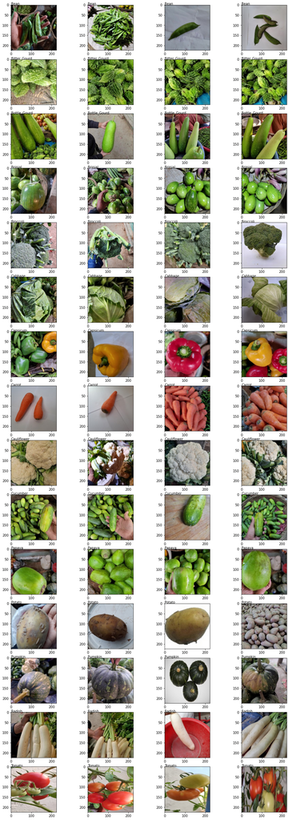

```python
# Plot some training images from the dataset
nrows = len(CLASS_LABELS)
ncols = 4
training_examples = []
example_labels = []

fig = plt.gcf()
fig.set_size_inches(ncols * 4, nrows * 3)

for c_label in CLASS_LABELS:
    training_class_dir = os.path.join(TRAIN_DIR, c_label)
    training_class_files = os.listdir(training_class_dir)
    for j in range(ncols):
        training_examples.append(training_class_dir + '/' + training_class_files[j])
        example_labels.append(c_label)
    # print(training_examples)
    # print(example_labels)

for i, img_path in enumerate(training_examples):
    # Set up subplot; subplot indices start at 1
    sp = plt.subplot(nrows, ncols, i+1)
    sp.text(0, 0, example_labels[i])
    # sp.axis('Off')
    img = mpimg.imread(img_path)
    plt.imshow(img)
plt.show()
```

```python
datagen_kwargs = dict(rescale=1./255, validation_split=VAL_SET_RATIO)
training_datagen = ImageDataGenerator(**datagen_kwargs)
validation_datagen = ImageDataGenerator(**datagen_kwargs)
dataflow_kwargs = dict(class_mode="categorical")

do_data_augmentation = True
if do_data_augmentation:
    training_datagen = ImageDataGenerator(rotation_range=45,
                                          horizontal_flip=True,
                                          vertical_flip=True,
                                          **datagen_kwargs)

print('Loading and pre-processing the training images...')
training_generator = training_datagen.flow_from_directory(directory=TRAIN_DIR,
                                                          target_size=TARGET_IMAGE_SIZE,
                                                          batch_size=BATCH_SIZE,
                                                          shuffle=True,
                                                          seed=RNG_SEED,
                                                          **dataflow_kwargs)
print('Number of training image batches per epoch of modeling:', len(training_generator))

print('Loading and pre-processing the validation images...')
validation_generator = validation_datagen.flow_from_directory(directory=VALID_DIR,
                                                              target_size=TARGET_IMAGE_SIZE,
                                                              batch_size=BATCH_SIZE,
                                                              shuffle=False,
                                                              **dataflow_kwargs)
print('Number of validation image batches per epoch of modeling:', len(validation_generator))
```

```
Loading and pre-processing the training images...
Found 15000 images belonging to 15 classes.
Number of training image batches per epoch of modeling: 469
Loading and pre-processing the validation images...
Found 3000 images belonging to 15 classes.
Number of validation image batches per epoch of modeling: 94
```

```python
if NOTIFY_STATUS: status_notify('(TensorFlow Multi-Class) Task 2 - Load and Prepare Images completed on ' + datetime.now().strftime('%A %B %d, %Y %I:%M:%S %p'))
```

# Task 3 - Define and Train Models

```python
if NOTIFY_STATUS: status_notify('(TensorFlow Multi-Class) Task 3 - Define and Train Models has begun on ' + datetime.now().strftime('%A %B %d, %Y %I:%M:%S %p'))
```

```python
# Define the function for plotting training results for comparison
def plot_metrics(history):
    fig, axs = plt.subplots(1, 2, figsize=(24, 15))
    metrics =  [TRAIN_LOSS, TRAIN_METRIC]
    for n, metric in enumerate(metrics):
        name = metric.replace("_"," ").capitalize()
        plt.subplot(2,2,n+1)
        plt.plot(history.epoch, history.history[metric], color='blue', label='Train')
        plt.plot(history.epoch, history.history['val_'+metric], color='red', linestyle="--", label='Val')
        plt.xlabel('Epoch')
        plt.ylabel(name)
        if metric == TRAIN_LOSS:
            plt.ylim([0, plt.ylim()[1]])
        else:
            plt.ylim([0.5, 1.1])
        plt.legend()
```

```python
# Define the baseline model for benchmarking
def create_nn_model(input_param=INPUT_IMAGE_SHAPE, output_param=NUM_CLASSES, dense_nodes=1024,
                    classifier_activation=CLASSIFIER_ACTIVATION, loss_param=DEFAULT_LOSS,
                    opt_param=DEFAULT_OPTIMIZER, metrics_param=DEFAULT_METRICS):
    base_model = keras.applications.vgg19.VGG19(include_top=False, weights='imagenet', input_shape=input_param)
    nn_model = keras.models.Sequential()
    nn_model.add(base_model)
    nn_model.add(keras.layers.Flatten())
    nn_model.add(keras.layers.Dense(dense_nodes, activation='relu')),
    nn_model.add(keras.layers.Dense(output_param, activation=classifier_activation))
    nn_model.compile(loss=loss_param, optimizer=opt_param, metrics=metrics_param)
    return nn_model
```

```python
# Initialize the neural network model and get the training results for plotting graph
start_time_module = datetime.now()
tf.keras.backend.clear_session()
reset_random()
baseline_model = create_nn_model()
baseline_model_history = baseline_model.fit(training_generator,
                                            epochs=MAX_EPOCHS,
                                            validation_data=validation_generator,
                                            verbose=1)
print('Total time for model fitting:', (datetime.now() - start_time_module))
```

[output not shown]

```
Downloading data from https://storage.googleapis.com/tensorflow/keras-applications/vgg19/vgg19_weights_tf_dim_ordering_tf_kernels_notop.h5
```

```
2022-01-23 21:00:03.042495: I tensorflow/compiler/mlir/mlir_graph_optimization_pass.cc:185] None of the MLIR Optimization Passes are enabled (registered 2)
```

```
2022-01-23 21:00:05.207275: I tensorflow/stream_executor/cuda/cuda_dnn.cc:381] Loaded cuDNN version 8204
```

```
Total time for model fitting: 0:28:32.541236
```

```python
baseline_model.summary()
```

```
Model: "sequential"
_________________________________________________________________
Layer (type)                 Output Shape              Param #
=================================================================
vgg19 (Functional)           (None, 7, 7, 512)         20024384
_________________________________________________________________
flatten (Flatten)            (None, 25088)             0
_________________________________________________________________
dense (Dense)                (None, 1024)              25691136
_________________________________________________________________
dense_1 (Dense)              (None, 15)                15375
=================================================================
Total params: 45,730,895
Trainable params: 45,730,895
Non-trainable params: 0
_________________________________________________________________
```

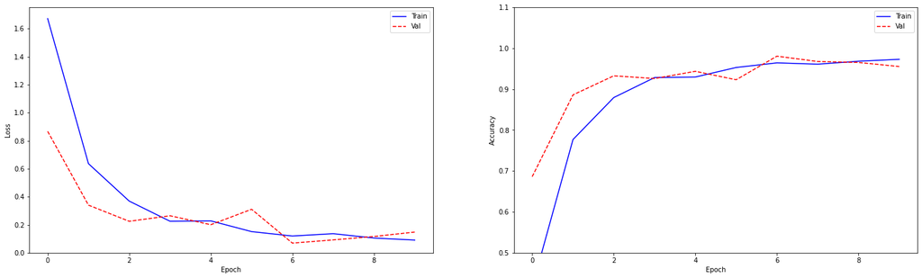

```python
plot_metrics(baseline_model_history)
```

```python
if NOTIFY_STATUS: status_notify('(TensorFlow Multi-Class) Task 3 - Define and Train Models completed on ' + datetime.now().strftime('%A %B %d, %Y %I:%M:%S %p'))
```

# Task 4 - Tune and Optimize Models

```python
if NOTIFY_STATUS: status_notify('(TensorFlow Multi-Class) Task 4 - Tune and Optimize Models has begun on ' + datetime.now().strftime('%A %B %d, %Y %I:%M:%S %p'))
```

```python
# Initialize the neural network model and get the training results for plotting graph
start_time_module = datetime.now()
learning_rate_reduction = ReduceLROnPlateau(monitor='val_accuracy', patience=2, verbose=1, factor=0.5, min_lr=0.000001)
TUNE_OPTIMIZER = tf.keras.optimizers.Adam(learning_rate=0.00005)
tf.keras.backend.clear_session()
reset_random()
tune_model = create_nn_model(opt_param=TUNE_OPTIMIZER)
tune_model_history = tune_model.fit(training_generator,
                                    epochs=MAX_EPOCHS,
                                    validation_data=validation_generator,
                                    callbacks=[learning_rate_reduction],
                                    verbose=1)
print('Total time for model fitting:', (datetime.now() - start_time_module))
```

```
Total time for model fitting: 0:27:12.126918
```

```python
tune_model.summary()
```

```
Model: "sequential"
_________________________________________________________________
Layer (type)                 Output Shape              Param #
=================================================================
vgg19 (Functional)           (None, 7, 7, 512)         20024384
_________________________________________________________________
flatten (Flatten)            (None, 25088)             0
_________________________________________________________________
dense (Dense)                (None, 1024)              25691136
_________________________________________________________________
dense_1 (Dense)              (None, 15)                15375
=================================================================
Total params: 45,730,895
Trainable params: 45,730,895
Non-trainable params: 0
_________________________________________________________________
```

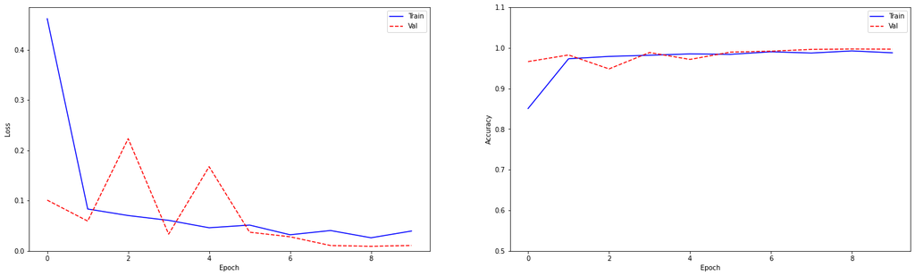

```python
plot_metrics(tune_model_history)
```

```python
if NOTIFY_STATUS: status_notify('(TensorFlow Multi-Class) Task 4 - Tune and Optimize Models completed on ' + datetime.now().strftime('%A %B %d, %Y %I:%M:%S %p'))
```

# Task 5 - Finalize Model and Make Predictions

```python
if NOTIFY_STATUS: status_notify('(TensorFlow Multi-Class) Task 5 - Finalize Model and Make Predictions has begun on ' + datetime.now().strftime('%A %B %d, %Y %I:%M:%S %p'))
```

### 5.a) Train the Final Model

```python
# # Train the model with the entire training set
# datagen_kwargs = dict(rescale=1./255)
# training_datagen = ImageDataGenerator(**datagen_kwargs)

# do_data_augmentation = True
# if do_data_augmentation:
#     training_datagen = ImageDataGenerator(rotation_range=45,
#                                           horizontal_flip=True,
#                                           vertical_flip=True,
#                                           **datagen_kwargs)

# print('Loading and pre-processing the training images...')
# training_generator = training_datagen.flow_from_directory(directory=TRAIN_DIR,
#                                                           target_size=TARGET_IMAGE_SIZE,
#                                                           batch_size=BATCH_SIZE,
#                                                           shuffle=True,
#                                                           seed=RNG_SEED,
#                                                           **dataflow_kwargs)
# print('Number of training image batches per epoch of modeling:', len(training_generator))
```

```python
FINAL_OPTIMIZER = tf.keras.optimizers.Adam(learning_rate=0.00005)
tf.keras.backend.clear_session()
reset_random()
final_model = create_nn_model(opt_param=FINAL_OPTIMIZER)
final_model.fit(training_generator, epochs=MAX_EPOCHS, verbose=1)
final_model.summary()
```

```
Model: "sequential"
_________________________________________________________________
Layer (type)                 Output Shape              Param #
=================================================================
vgg19 (Functional)           (None, 7, 7, 512)         20024384
_________________________________________________________________
flatten (Flatten)            (None, 25088)             0
_________________________________________________________________
dense (Dense)                (None, 1024)              25691136
_________________________________________________________________
dense_1 (Dense)              (None, 15)                15375
=================================================================
Total params: 45,730,895
Trainable params: 45,730,895
Non-trainable params: 0
_________________________________________________________________
```

### 5.b) Load Test Dataset and Make Predictions

```python
# Brief listing of test image files for each class
for c_label in CLASS_LABELS:
    test_class_dir = os.path.join(TEST_DIR, c_label)
    test_class_files = os.listdir(test_class_dir)
    print('Number of test images for', c_label, ':', len(os.listdir(test_class_dir)))
    print('Training samples for', c_label, ':')
    print(test_class_files[:5],'\n')
```

```
Number of test images for Bean : 200
Training samples for Bean :
['0621.jpg', '0534.jpg', '0532.jpg', '0002.jpg', '0507.jpg']

Number of test images for Bitter_Gourd : 200
Training samples for Bitter_Gourd :
['1332.jpg', '1325.jpg', '1305.jpg', '1277.jpg', '1367.jpg']

Number of test images for Bottle_Gourd : 200
Training samples for Bottle_Gourd :
['1182.jpg', '1012.jpg', '1055.jpg', '1052.jpg', '1040.jpg']

Number of test images for Brinjal : 200
Training samples for Brinjal :
['1182.jpg', '1012.jpg', '1055.jpg', '0925.jpg', '1052.jpg']

Number of test images for Broccoli : 200
Training samples for Broccoli :
['1182.jpg', '1012.jpg', '1055.jpg', '1052.jpg', '1040.jpg']

Number of test images for Cabbage : 200
Training samples for Cabbage :
['1182.jpg', '1012.jpg', '1055.jpg', '1052.jpg', '1040.jpg']

Number of test images for Capsicum : 200
Training samples for Capsicum :
['1182.jpg', '1012.jpg', '1055.jpg', '1052.jpg', '1040.jpg']

Number of test images for Carrot : 200
Training samples for Carrot :
['1182.jpg', '1012.jpg', '1055.jpg', '1052.jpg', '1040.jpg']

Number of test images for Cauliflower : 200
Training samples for Cauliflower :
['1182.jpg', '1055.jpg', '1052.jpg', '1112.jpg', '1226.jpg']

Number of test images for Cucumber : 200
Training samples for Cucumber :
['1182.jpg', '1012.jpg', '1055.jpg', '1052.jpg', '1040.jpg']

Number of test images for Papaya : 200
Training samples for Papaya :
['1332.jpg', '1305.jpg', '1277.jpg', '1367.jpg', '1317.jpg']

Number of test images for Potato : 200
Training samples for Potato :
['1182.jpg', '1012.jpg', '1055.jpg', '1052.jpg', '1040.jpg']

Number of test images for Pumpkin : 200
Training samples for Pumpkin :
['1182.jpg', '1012.jpg', '1055.jpg', '1052.jpg', '1040.jpg']

Number of test images for Radish : 200
Training samples for Radish :
['1182.jpg', '1012.jpg', '1055.jpg', '1052.jpg', '1040.jpg']

Number of test images for Tomato : 200
Training samples for Tomato :
['1182.jpg', '1012.jpg', '1055.jpg', '1052.jpg', '1040.jpg']
```

```python
print('Loading and pre-processing the test images...')
test_datagen = ImageDataGenerator(rescale=1/255)
test_generator = test_datagen.flow_from_directory(directory=TEST_DIR,
                                                  target_size=TARGET_IMAGE_SIZE,
                                                  batch_size=BATCH_SIZE,
                                                  shuffle=False,
                                                  **dataflow_kwargs)
print('Number of image batches per epoch of modeling:', len(test_generator))
```

```
Loading and pre-processing the test images...
Found 3000 images belonging to 15 classes.
Number of image batches per epoch of modeling: 94
```

```python
# Print the labels used for the modeling
print(test_generator.class_indices)
```

```
{'Bean': 0, 'Bitter_Gourd': 1, 'Bottle_Gourd': 2, 'Brinjal': 3, 'Broccoli': 4, 'Cabbage': 5, 'Capsicum': 6, 'Carrot': 7, 'Cauliflower': 8, 'Cucumber': 9, 'Papaya': 10, 'Potato': 11, 'Pumpkin': 12, 'Radish': 13, 'Tomato': 14}
```

```python
final_model.evaluate(test_generator, verbose=1)
```

```
[0.046830300241708755, 0.9866666793823242]
```

```python
test_pred = final_model.predict(test_generator)
test_predictions = np.argmax(test_pred, axis=-1)
test_original = test_generator.labels
print('Accuracy Score:', accuracy_score(test_original, test_predictions))
print(confusion_matrix(test_original, test_predictions))
print(classification_report(test_original, test_predictions))
```

```
Accuracy Score: 0.9866666666666667
[[188   0   0   0  12   0   0   0   0   0   0   0   0   0   0]
 [  1 198   0   0   0   0   0   0   0   0   0   0   1   0   0]
 [  1   0 198   0   0   0   0   0   0   0   1   0   0   0   0]
 [  0   0   0 189   0   4   0   0   0   0   1   0   2   0   4]
 [  0   0   0   0 200   0   0   0   0   0   0   0   0   0   0]
 [  0   0   0   0   0 200   0   0   0   0   0   0   0   0   0]
 [  0   0   0   0   0   0 200   0   0   0   0   0   0   0   0]
 [  0   0   0   0   0   0   0 200   0   0   0   0   0   0   0]
 [  1   0   0   0   0   0   0   0 197   0   0   1   1   0   0]
 [  0   0   0   0   0   0   0   0   0 200   0   0   0   0   0]
 [  0   0   0   0   0   3   0   0   0   0 197   0   0   0   0]
 [  0   0   0   0   0   0   0   2   0   0   0 198   0   0   0]
 [  0   0   0   0   0   0   0   0   0   0   0   0 200   0   0]
 [  0   0   0   0   0   0   0   3   0   0   0   1   0 196   0]
 [  0   0   0   0   0   0   0   1   0   0   0   0   0   0 199]]
              precision    recall  f1-score   support

           0       0.98      0.94      0.96       200
           1       1.00      0.99      0.99       200
           2       1.00      0.99      0.99       200
           3       1.00      0.94      0.97       200
           4       0.94      1.00      0.97       200
           5       0.97      1.00      0.98       200
           6       1.00      1.00      1.00       200
           7       0.97      1.00      0.99       200
           8       1.00      0.98      0.99       200
           9       1.00      1.00      1.00       200
          10       0.99      0.98      0.99       200
          11       0.99      0.99      0.99       200
          12       0.98      1.00      0.99       200
          13       1.00      0.98      0.99       200
          14       0.98      0.99      0.99       200

    accuracy                           0.99      3000
   macro avg       0.99      0.99      0.99      3000
weighted avg       0.99      0.99      0.99      3000
```

```python
if NOTIFY_STATUS: status_notify('(TensorFlow Multi-Class) Task 5 - Finalize Model and Make Predictions completed on ' + datetime.now().strftime('%A %B %d, %Y %I:%M:%S %p'))
```

```python
print ('Total time for the script:',(datetime.now() - START_TIME_SCRIPT))
```

```
Total time for the script: 1:47:35.747953
```